# 18110213_DaoNgocPhuongThanh_ DM Lab08

```python
# import basic libraries
import numpy as np
import pandas as pd
from matplotlib import pyplot as plt
import warnings
warnings.filterwarnings('ignore')
```

```python
from sklearn.cluster import MeanShift, KMeans, MiniBatchKMeans
from sklearn import preprocessing, model_selection
from sklearn.preprocessing import LabelEncoder, MinMaxScaler
```

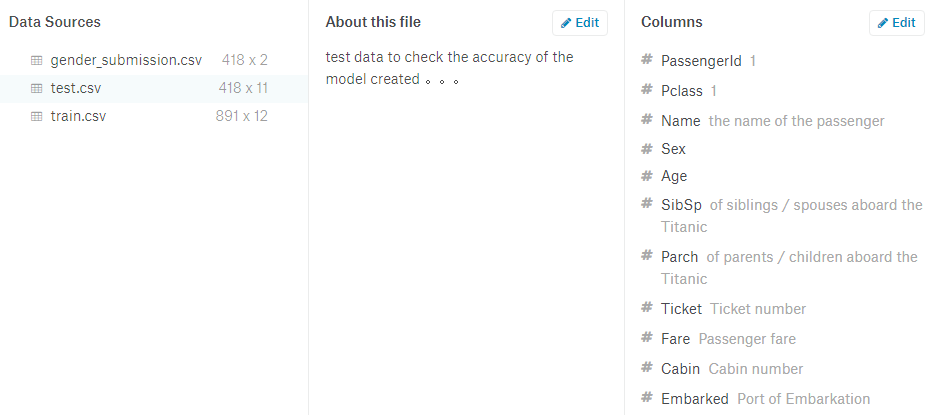

```python
# Show the problem
from IPython.display import Image
path = r"C:\Users\Thanh\Documents\Data mining\Data_Mining_Lab08\\"
Image(filename= path + "Titanic_Disaster.png")
```

```python
data = pd.read_excel(path + "Titanic_Disaster.xls")
data.head()
```

|  | pclass | survived | name | sex | age | sibsp | parch | ticket | fare | cabin | embarked | boat | body | home.dest |
| --- | --- | --- | --- | --- | --- | --- | --- | --- | --- | --- | --- | --- | --- | --- |
| 0 | 1 | 1 | Allen, Miss. Elisabeth Walton | female | 29.0000 | 0 | 0 | 24160 | 211.3375 | B5 | S | 2 | NaN | St Louis, MO |
| 1 | 1 | 1 | Allison, Master. Hudson Trevor | male | 0.9167 | 1 | 2 | 113781 | 151.5500 | C22 C26 | S | 11 | NaN | Montreal, PQ / Chesterville, ON |
| 2 | 1 | 0 | Allison, Miss. Helen Loraine | female | 2.0000 | 1 | 2 | 113781 | 151.5500 | C22 C26 | S | NaN | NaN | Montreal, PQ / Chesterville, ON |
| 3 | 1 | 0 | Allison, Mr. Hudson Joshua Creighton | male | 30.0000 | 1 | 2 | 113781 | 151.5500 | C22 C26 | S | NaN | 135.0 | Montreal, PQ / Chesterville, ON |
| 4 | 1 | 0 | Allison, Mrs. Hudson J C (Bessie Waldo Daniels) | female | 25.0000 | 1 | 2 | 113781 | 151.5500 | C22 C26 | S | NaN | NaN | Montreal, PQ / Chesterville, ON |

```python
data.info()
```

```
<class 'pandas.core.frame.DataFrame'>
RangeIndex: 1309 entries, 0 to 1308
Data columns (total 14 columns):
 #   Column     Non-Null Count  Dtype
---  ------     --------------  -----
 0   pclass     1309 non-null   int64
 1   survived   1309 non-null   int64
 2   name       1309 non-null   object
 3   sex        1309 non-null   object
 4   age        1046 non-null   float64
 5   sibsp      1309 non-null   int64
 6   parch      1309 non-null   int64
 7   ticket     1309 non-null   object
 8   fare       1308 non-null   float64
 9   cabin      295 non-null    object
 10  embarked   1307 non-null   object
 11  boat       486 non-null    object
 12  body       121 non-null    float64
 13  home.dest  745 non-null    object
dtypes: float64(3), int64(4), object(7)
memory usage: 143.3+ KB
```

### Feature Engineering

```python
def toNumeric(dataframe, fromAtt, toAtt):
  from sklearn import preprocessing
  if dataframe[fromAtt].dtype == type(object):
      le = preprocessing.LabelEncoder()# Dummies / One Hot Encoder
      dataframe[toAtt] = le.fit_transform(dataframe[fromAtt].astype(str))
  return dataframe
```

```python
data = toNumeric(data, 'sex', 'n_sex')
data = toNumeric(data, 'cabin', 'n_cabin')
data = toNumeric(data, 'embarked', 'n_embarked')
data = toNumeric(data, 'boat', 'n_boat')
data.fillna(0,inplace=True)

data.head()
```

|  | pclass | survived | name | sex | age | sibsp | parch | ticket | fare | cabin | embarked | boat | body | home.dest | n_sex | n_cabin | n_embarked | n_boat |
| --- | --- | --- | --- | --- | --- | --- | --- | --- | --- | --- | --- | --- | --- | --- | --- | --- | --- | --- |
| 0 | 1 | 1 | Allen, Miss. Elisabeth Walton | female | 29.0000 | 0 | 0 | 24160 | 211.3375 | B5 | S | 2 | 0.0 | St Louis, MO | 0 | 43 | 2 | 11 |
| 1 | 1 | 1 | Allison, Master. Hudson Trevor | male | 0.9167 | 1 | 2 | 113781 | 151.5500 | C22 C26 | S | 11 | 0.0 | Montreal, PQ / Chesterville, ON | 1 | 79 | 2 | 2 |
| 2 | 1 | 0 | Allison, Miss. Helen Loraine | female | 2.0000 | 1 | 2 | 113781 | 151.5500 | C22 C26 | S | 0 | 0.0 | Montreal, PQ / Chesterville, ON | 0 | 79 | 2 | 27 |
| 3 | 1 | 0 | Allison, Mr. Hudson Joshua Creighton | male | 30.0000 | 1 | 2 | 113781 | 151.5500 | C22 C26 | S | 0 | 135.0 | Montreal, PQ / Chesterville, ON | 1 | 79 | 2 | 27 |
| 4 | 1 | 0 | Allison, Mrs. Hudson J C (Bessie Waldo Daniels) | female | 25.0000 | 1 | 2 | 113781 | 151.5500 | C22 C26 | S | 0 | 0.0 | Montreal, PQ / Chesterville, ON | 0 | 79 | 2 | 27 |

```python
FeatureList = ['pclass','n_sex','age','sibsp','parch','fare','n_cabin','n_embarked','n_boat']
X = data[FeatureList].astype(float)
y = data['survived']
display(X.head())
display(y.head())
```

|  | pclass | n_sex | age | sibsp | parch | fare | n_cabin | n_embarked | n_boat |
| --- | --- | --- | --- | --- | --- | --- | --- | --- | --- |
| 0 | 1.0 | 0.0 | 29.0000 | 0.0 | 0.0 | 211.3375 | 43.0 | 2.0 | 11.0 |
| 1 | 1.0 | 1.0 | 0.9167 | 1.0 | 2.0 | 151.5500 | 79.0 | 2.0 | 2.0 |
| 2 | 1.0 | 0.0 | 2.0000 | 1.0 | 2.0 | 151.5500 | 79.0 | 2.0 | 27.0 |
| 3 | 1.0 | 1.0 | 30.0000 | 1.0 | 2.0 | 151.5500 | 79.0 | 2.0 | 27.0 |
| 4 | 1.0 | 0.0 | 25.0000 | 1.0 | 2.0 | 151.5500 | 79.0 | 2.0 | 27.0 |

```
0    1
1    1
2    0
3    0
4    0
Name: survived, dtype: int64
```

### Đếm tần suất Survived 1 và 0 trên dữ liệu

```python
# Count the occurrences of survived and no survived and print them
occ = data['survived'].value_counts()
occ
```

```
0    809
1    500
Name: survived, dtype: int64
```

```python
# DBSCan gives us a metric LOFFactor for each data points
# if LOFFactor greater than 3.0 means Outliers or Noises
# if LOFFactor greater than 2.0 means Border Points and others are Core Points
def CalculateLOFFactor(DataFrame, FeatureList, neighbors = 10):
  import numpy as np
  from sklearn.neighbors import LocalOutlierFactor

  clf = LocalOutlierFactor(n_neighbors=neighbors)
  AttData = DataFrame.loc[:, FeatureList].values
  y_pred = clf.fit_predict(AttData)
  AttData_scores = -1 * clf.negative_outlier_factor_
  LOFFactorData = pd.DataFrame(AttData_scores, columns=['LOF'])
  return LOFFactorData
```

```python
LOFFactorPerPoints = CalculateLOFFactor(data, FeatureList, neighbors = 11)
data['LOFFactorMetric'] = LOFFactorPerPoints
display(data.head())
```

|  | pclass | survived | name | sex | age | sibsp | parch | ticket | fare | cabin | embarked | boat | body | home.dest | n_sex | n_cabin | n_embarked | n_boat | LOFFactorMetric |
| --- | --- | --- | --- | --- | --- | --- | --- | --- | --- | --- | --- | --- | --- | --- | --- | --- | --- | --- | --- |
| 0 | 1 | 1 | Allen, Miss. Elisabeth Walton | female | 29.0000 | 0 | 0 | 24160 | 211.3375 | B5 | S | 2 | 0.0 | St Louis, MO | 0 | 43 | 2 | 11 | 1.069072 |
| 1 | 1 | 1 | Allison, Master. Hudson Trevor | male | 0.9167 | 1 | 2 | 113781 | 151.5500 | C22 C26 | S | 11 | 0.0 | Montreal, PQ / Chesterville, ON | 1 | 79 | 2 | 2 | 1.092018 |
| 2 | 1 | 0 | Allison, Miss. Helen Loraine | female | 2.0000 | 1 | 2 | 113781 | 151.5500 | C22 C26 | S | 0 | 0.0 | Montreal, PQ / Chesterville, ON | 0 | 79 | 2 | 27 | 1.078429 |
| 3 | 1 | 0 | Allison, Mr. Hudson Joshua Creighton | male | 30.0000 | 1 | 2 | 113781 | 151.5500 | C22 C26 | S | 0 | 135.0 | Montreal, PQ / Chesterville, ON | 1 | 79 | 2 | 27 | 1.011304 |
| 4 | 1 | 0 | Allison, Mrs. Hudson J C (Bessie Waldo Daniels) | female | 25.0000 | 1 | 2 | 113781 | 151.5500 | C22 C26 | S | 0 | 0.0 | Montreal, PQ / Chesterville, ON | 0 | 79 | 2 | 27 | 1.008787 |

```python
NoiseData = data[data['LOFFactorMetric'] >= 3]
NormalData = data[data['LOFFactorMetric'] < 3]
print(NoiseData.shape)
print('Noise Data Index : ', NoiseData.index)
display(NoiseData.head())
```

```
(70, 19)
Noise Data Index :  Int64Index([  49,   50,   70,  183,  223,  234,  302,  363,  384,  410,  473,
             477,  528,  568,  581,  682,  800,  802,  816,  854,  865,  873,
             874,  898,  921,  929,  930,  931,  940,  963,  971,  973,  976,
             983,  994,  997,  998, 1012, 1013, 1014, 1024, 1030, 1033, 1037,
            1054, 1070, 1072, 1076, 1080, 1088, 1095, 1109, 1115, 1136, 1155,
            1167, 1168, 1193, 1198, 1214, 1217, 1228, 1230, 1241, 1242, 1249,
            1268, 1283, 1291, 1292],
           dtype='int64')
```

|  | pclass | survived | name | sex | age | sibsp | parch | ticket | fare | cabin | embarked | boat | body | home.dest | n_sex | n_cabin | n_embarked | n_boat | LOFFactorMetric |
| --- | --- | --- | --- | --- | --- | --- | --- | --- | --- | --- | --- | --- | --- | --- | --- | --- | --- | --- | --- |
| 49 | 1 | 1 | Cardeza, Mr. Thomas Drake Martinez | male | 36.0 | 0 | 1 | PC 17755 | 512.3292 | B51 B53 B55 | C | 3 | 0.0 | Austria-Hungary / Germantown, Philadelphia, PA | 1 | 45 | 0 | 12 | 4.800880 |
| 50 | 1 | 1 | Cardeza, Mrs. James Warburton Martinez (Charlo... | female | 58.0 | 0 | 1 | PC 17755 | 512.3292 | B51 B53 B55 | C | 3 | 0.0 | Germantown, Philadelphia, PA | 0 | 45 | 0 | 12 | 4.678324 |
| 70 | 1 | 0 | Chisholm, Mr. Roderick Robert Crispin | male | 0.0 | 0 | 0 | 112051 | 0.0000 | 0 | S | 0 | 0.0 | Liverpool, England / Belfast | 1 | 186 | 2 | 27 | 3.846474 |
| 183 | 1 | 1 | Lesurer, Mr. Gustave J | male | 35.0 | 0 | 0 | PC 17755 | 512.3292 | B101 | C | 3 | 0.0 | 0 | 1 | 21 | 0 | 12 | 4.822853 |
| 223 | 1 | 0 | Parr, Mr. William Henry Marsh | male | 0.0 | 0 | 0 | 112052 | 0.0000 | 0 | S | 0 | 0.0 | Belfast | 1 | 186 | 2 | 27 | 3.846474 |

```python
# sử dụng data đã loại bỏ outlier
data=NormalData
X = data[FeatureList].astype(float)
y = data['survived']
```

### Đếm lại tần suất Survived 1 và 0 trên dữ liệu đã loại bỏ outlier

```python
# Count the occurrences of survived and no survived and print them
occ = data['survived'].value_counts()
occ
```

```
0    751
1    488
Name: survived, dtype: int64
```

### Thực hiện Meanshift để xác định bao nhiêu nhóm là nên gom trước

```python
clf = MeanShift()
clf.fit(X)
```

```
MeanShift(bandwidth=None, bin_seeding=False, cluster_all=True, min_bin_freq=1,
     n_jobs=None, seeds=None)
```

```python
labels = clf.labels_
print("The number of clusters by Meanshift", len(set(labels)))
display(set(labels))
```

```
The number of clusters by Meanshift 7
```

```
{0, 1, 2, 3, 4, 5, 6}
```

### Sau khi biết số nhóm thì tiến hành lưu thông tin nhóm và center từng nhóm theo các phương pháp :

- Kmeans
- EM-GMM
- MeanShift

#### 1/ MeanShift

```python
cluster_centers = clf.cluster_centers_
ClusterCenterData_meanshift = pd.DataFrame.from_records(cluster_centers)
ClusterCenterData_meanshift.columns = X.columns
ClusterCenterData_meanshift['cluster_meanshift'] = ClusterCenterData_meanshift.index
display(ClusterCenterData_meanshift)
```

|  | pclass | n_sex | age | sibsp | parch | fare | n_cabin | n_embarked | n_boat | cluster_meanshift |
| --- | --- | --- | --- | --- | --- | --- | --- | --- | --- | --- |
| 0 | 2.619703 | 0.674788 | 22.051642 | 0.456568 | 0.361229 | 15.806611 | 185.297669 | 1.618644 | 21.989407 | 0 |
| 1 | 1.050000 | 0.537500 | 38.443750 | 0.487500 | 0.150000 | 54.990211 | 123.675000 | 1.162500 | 17.612500 | 1 |
| 2 | 1.000000 | 0.560000 | 40.100000 | 0.440000 | 0.253333 | 55.093504 | 41.493333 | 1.146667 | 19.373333 | 2 |
| 3 | 1.000000 | 0.379310 | 31.824714 | 0.620690 | 0.827586 | 133.397983 | 84.482759 | 0.965517 | 19.620690 | 3 |
| 4 | 1.000000 | 0.370370 | 37.092593 | 1.074074 | 1.296296 | 241.168981 | 73.962963 | 0.740741 | 16.851852 | 4 |
| 5 | 1.000000 | 0.352941 | 31.411765 | 0.529412 | 0.470588 | 133.258824 | 168.529412 | 0.705882 | 15.705882 | 5 |
| 6 | 1.000000 | 0.250000 | 31.500000 | 0.000000 | 0.000000 | 232.190625 | 186.000000 | 0.500000 | 16.000000 | 6 |

```python
data['cluster_meanshift']= labels
display(data.head())
```

|  | pclass | survived | name | sex | age | sibsp | parch | ticket | fare | cabin | embarked | boat | body | home.dest | n_sex | n_cabin | n_embarked | n_boat | LOFFactorMetric | cluster_meanshift |
| --- | --- | --- | --- | --- | --- | --- | --- | --- | --- | --- | --- | --- | --- | --- | --- | --- | --- | --- | --- | --- |
| 0 | 1 | 1 | Allen, Miss. Elisabeth Walton | female | 29.0000 | 0 | 0 | 24160 | 211.3375 | B5 | S | 2 | 0.0 | St Louis, MO | 0 | 43 | 2 | 11 | 1.069072 | 4 |
| 1 | 1 | 1 | Allison, Master. Hudson Trevor | male | 0.9167 | 1 | 2 | 113781 | 151.5500 | C22 C26 | S | 11 | 0.0 | Montreal, PQ / Chesterville, ON | 1 | 79 | 2 | 2 | 1.092018 | 3 |
| 2 | 1 | 0 | Allison, Miss. Helen Loraine | female | 2.0000 | 1 | 2 | 113781 | 151.5500 | C22 C26 | S | 0 | 0.0 | Montreal, PQ / Chesterville, ON | 0 | 79 | 2 | 27 | 1.078429 | 3 |
| 3 | 1 | 0 | Allison, Mr. Hudson Joshua Creighton | male | 30.0000 | 1 | 2 | 113781 | 151.5500 | C22 C26 | S | 0 | 135.0 | Montreal, PQ / Chesterville, ON | 1 | 79 | 2 | 27 | 1.011304 | 3 |
| 4 | 1 | 0 | Allison, Mrs. Hudson J C (Bessie Waldo Daniels) | female | 25.0000 | 1 | 2 | 113781 | 151.5500 | C22 C26 | S | 0 | 0.0 | Montreal, PQ / Chesterville, ON | 0 | 79 | 2 | 27 | 1.008787 | 3 |

```python
n_clusters_ = len(np.unique(labels))
survival_rates = {}
for i in range(n_clusters_):
    temp_df = data[ (data['cluster_meanshift']==float(i)) ]
    survival_cluster = temp_df[  (temp_df['survived'] == 1) ]
    survival_rate = len(survival_cluster) / len(temp_df)
    survival_rates[i] = survival_rate

print("Survival_rates in each clusters : ")
print(survival_rates)
```

```
Survival_rates in each clusters :
{0: 0.3213552361396304, 1: 0.6966292134831461, 2: 0.5955056179775281, 3: 0.6896551724137931, 4: 0.6333333333333333, 5: 0.75, 6: 0.75}
```

#### 2/ Kmeans

```python
from sklearn.cluster import KMeans
FeatureList = ['pclass','n_sex','age','sibsp','parch','fare','n_cabin','n_embarked','n_boat']
X = data[FeatureList].astype(float)
kmeans = KMeans(n_clusters=7, random_state=0).fit(X)
kmeans
```

```
KMeans(algorithm='auto', copy_x=True, init='k-means++', max_iter=300,
    n_clusters=7, n_init=10, n_jobs=None, precompute_distances='auto',
    random_state=0, tol=0.0001, verbose=0)
```

```python
cluster_centers = kmeans.cluster_centers_
ClusterCenterData_kmeans = pd.DataFrame.from_records(cluster_centers)
ClusterCenterData_kmeans.columns = X.columns
ClusterCenterData_kmeans['cluster_Kmeans'] = ClusterCenterData_kmeans.index
display(ClusterCenterData_kmeans)
```

|  | pclass | n_sex | age | sibsp | parch | fare | n_cabin | n_embarked | n_boat | cluster_Kmeans |
| --- | --- | --- | --- | --- | --- | --- | --- | --- | --- | --- |
| 0 | 1.833333 | 0.583333 | 23.767857 | 1.654762 | 1.023810 | 65.693201 | 180.380952 | 1.476190 | 21.869048 | 0 |
| 1 | 1.000000 | 0.365854 | 33.046749 | 0.585366 | 0.780488 | 134.480485 | 106.951220 | 0.878049 | 18.463415 | 1 |
| 2 | 2.755245 | 0.611888 | 3.221154 | 0.755245 | 0.545455 | 17.110926 | 185.622378 | 1.339161 | 20.650350 | 2 |
| 3 | 1.065789 | 0.539474 | 35.953947 | 0.486842 | 0.157895 | 55.732787 | 112.776316 | 1.065789 | 18.750000 | 3 |
| 4 | 1.000000 | 0.607143 | 36.839286 | 0.357143 | 0.250000 | 50.210618 | 37.416667 | 1.261905 | 19.880952 | 4 |
| 5 | 1.000000 | 0.352941 | 34.867647 | 0.852941 | 1.088235 | 237.787624 | 86.147059 | 0.823529 | 16.705882 | 5 |
| 6 | 2.577287 | 0.703470 | 30.826498 | 0.276025 | 0.244479 | 13.565555 | 185.126183 | 1.746057 | 22.525237 | 6 |

```python
data['cluster_Kmeans'] = kmeans.predict(data[FeatureList])
display(data.head())
```

|  | pclass | survived | name | sex | age | sibsp | parch | ticket | fare | cabin | ... | boat | body | home.dest | n_sex | n_cabin | n_embarked | n_boat | LOFFactorMetric | cluster_meanshift | cluster_Kmeans |
| --- | --- | --- | --- | --- | --- | --- | --- | --- | --- | --- | --- | --- | --- | --- | --- | --- | --- | --- | --- | --- | --- |
| 0 | 1 | 1 | Allen, Miss. Elisabeth Walton | female | 29.0000 | 0 | 0 | 24160 | 211.3375 | B5 | ... | 2 | 0.0 | St Louis, MO | 0 | 43 | 2 | 11 | 1.069072 | 4 | 5 |
| 1 | 1 | 1 | Allison, Master. Hudson Trevor | male | 0.9167 | 1 | 2 | 113781 | 151.5500 | C22 C26 | ... | 11 | 0.0 | Montreal, PQ / Chesterville, ON | 1 | 79 | 2 | 2 | 1.092018 | 3 | 1 |
| 2 | 1 | 0 | Allison, Miss. Helen Loraine | female | 2.0000 | 1 | 2 | 113781 | 151.5500 | C22 C26 | ... | 0 | 0.0 | Montreal, PQ / Chesterville, ON | 0 | 79 | 2 | 27 | 1.078429 | 3 | 1 |
| 3 | 1 | 0 | Allison, Mr. Hudson Joshua Creighton | male | 30.0000 | 1 | 2 | 113781 | 151.5500 | C22 C26 | ... | 0 | 135.0 | Montreal, PQ / Chesterville, ON | 1 | 79 | 2 | 27 | 1.011304 | 3 | 1 |
| 4 | 1 | 0 | Allison, Mrs. Hudson J C (Bessie Waldo Daniels) | female | 25.0000 | 1 | 2 | 113781 | 151.5500 | C22 C26 | ... | 0 | 0.0 | Montreal, PQ / Chesterville, ON | 0 | 79 | 2 | 27 | 1.008787 | 3 | 1 |

5 rows × 21 columns

```python
n_clusters_ = len(np.unique(data['cluster_Kmeans'].values))
survival_rates = {}
for i in range(n_clusters_):
    temp_df = data[ (data['cluster_Kmeans']==float(i)) ]
    survival_cluster = temp_df[  (temp_df['survived'] == 1) ]
    survival_rate = len(survival_cluster) / len(temp_df)
    survival_rates[i] = survival_rate

print("Survival_rates in each clusters : ")
print(survival_rates)
```

```
Survival_rates in each clusters :
{0: 0.42857142857142855, 1: 0.7317073170731707, 2: 0.41754385964912283, 3: 0.6710526315789473, 4: 0.5952380952380952, 5: 0.6470588235294118, 6: 0.28346456692913385}
```

#### 3/ EM-GMM

```python
def ClusterByGaussianMixture(data, FeatureList, nCluster, ClusterColName = 'cluster_GMM'):
  data_train = data.loc[:,FeatureList]

  from sklearn.mixture import GaussianMixture
  Gmm_Model = GaussianMixture(n_components=nCluster, random_state=1234)
  Gmm_Model.fit(data_train)
  predict_label_train = Gmm_Model.fit_predict(data_train)
  data[ClusterColName] = predict_label_train

  print(data[ClusterColName].unique())

  # ClusterData = pd.DataFrame(columns=FeatureList + ['ClusterNo', 'NumElements'])
  ClusterData_GMM = pd.DataFrame(Gmm_Model.means_)
  ClusterData_GMM.columns = FeatureList
  ClusterData_GMM["ClusterNo"] = ClusterData_GMM.index
  ClusterData_GMM["NumElementRate"] = Gmm_Model.weights_

  return Gmm_Model, ClusterData_GMM, data
```

```python
FeatureList = ['pclass','n_sex','age','sibsp','parch','fare','n_cabin','n_embarked','n_boat']
nCluster = 7
Gmm_Model, ClusterGMMData, data = ClusterByGaussianMixture(data, FeatureList, nCluster)

display(data.head())
display(ClusterGMMData.head(10))
```

```
[6 3 1 4 0 5 2]
```

|  | pclass | survived | name | sex | age | sibsp | parch | ticket | fare | cabin | ... | body | home.dest | n_sex | n_cabin | n_embarked | n_boat | LOFFactorMetric | cluster_meanshift | cluster_Kmeans | cluster_GMM |
| --- | --- | --- | --- | --- | --- | --- | --- | --- | --- | --- | --- | --- | --- | --- | --- | --- | --- | --- | --- | --- | --- |
| 0 | 1 | 1 | Allen, Miss. Elisabeth Walton | female | 29.0000 | 0 | 0 | 24160 | 211.3375 | B5 | ... | 0.0 | St Louis, MO | 0 | 43 | 2 | 11 | 1.069072 | 4 | 5 | 6 |
| 1 | 1 | 1 | Allison, Master. Hudson Trevor | male | 0.9167 | 1 | 2 | 113781 | 151.5500 | C22 C26 | ... | 0.0 | Montreal, PQ / Chesterville, ON | 1 | 79 | 2 | 2 | 1.092018 | 3 | 1 | 3 |
| 2 | 1 | 0 | Allison, Miss. Helen Loraine | female | 2.0000 | 1 | 2 | 113781 | 151.5500 | C22 C26 | ... | 0.0 | Montreal, PQ / Chesterville, ON | 0 | 79 | 2 | 27 | 1.078429 | 3 | 1 | 3 |
| 3 | 1 | 0 | Allison, Mr. Hudson Joshua Creighton | male | 30.0000 | 1 | 2 | 113781 | 151.5500 | C22 C26 | ... | 135.0 | Montreal, PQ / Chesterville, ON | 1 | 79 | 2 | 27 | 1.011304 | 3 | 1 | 3 |
| 4 | 1 | 0 | Allison, Mrs. Hudson J C (Bessie Waldo Daniels) | female | 25.0000 | 1 | 2 | 113781 | 151.5500 | C22 C26 | ... | 0.0 | Montreal, PQ / Chesterville, ON | 0 | 79 | 2 | 27 | 1.008787 | 3 | 1 | 3 |

5 rows × 22 columns

|  | pclass | n_sex | age | sibsp | parch | fare | n_cabin | n_embarked | n_boat | ClusterNo | NumElementRate |
| --- | --- | --- | --- | --- | --- | --- | --- | --- | --- | --- | --- |
| 0 | 2.707594 | 0.686255 | 22.307458 | 0.288897 | 0.232602 | 12.933138 | 186.000000 | 1.599978 | 22.103603 | 0 | 0.643644 |
| 1 | 1.000000 | 0.607511 | 34.017671 | 0.375500 | 0.000000 | 58.871240 | 111.030564 | 1.169348 | 19.830236 | 1 | 0.180494 |
| 2 | 2.821283 | 0.549603 | 15.442289 | 2.709886 | 1.873099 | 41.350572 | 185.803363 | 1.941008 | 23.762805 | 2 | 0.082087 |
| 3 | 1.000000 | 0.447967 | 35.815755 | 0.506935 | 1.103988 | 137.203228 | 77.607850 | 1.062152 | 18.428609 | 3 | 0.037348 |
| 4 | 1.000000 | 0.438434 | 37.404146 | 0.378465 | 1.143121 | 77.740035 | 149.743735 | 1.002884 | 19.367338 | 4 | 0.022537 |
| 5 | 2.250008 | 0.499980 | 23.208571 | 0.124995 | 0.291678 | 13.902497 | 157.626993 | 1.458357 | 13.666217 | 5 | 0.019372 |
| 6 | 1.000000 | 0.277957 | 33.504266 | 1.278647 | 1.834230 | 251.615305 | 56.953129 | 0.999857 | 13.556602 | 6 | 0.014518 |

```python
n_clusters_ = len(np.unique(data['cluster_GMM'].values))
survival_rates = {}
for i in range(n_clusters_):
    temp_df = data[ (data['cluster_GMM']==float(i)) ]
    survival_cluster = temp_df[  (temp_df['survived'] == 1) ]
    survival_rate = len(survival_cluster) / len(temp_df)
    survival_rates[i] = survival_rate

print("Survival_rates in each clusters : ")
print(survival_rates)
```

```
Survival_rates in each clusters :
{0: 0.3124215809284818, 1: 0.5911111111111111, 2: 0.23529411764705882, 3: 0.6521739130434783, 4: 0.7037037037037037, 5: 0.7916666666666666, 6: 0.7777777777777778}
```

### Sau đó tiến hành Hierachy Clustering theo từng kết quả center ở trên

### Nhìn vào Hierachy Clustering để xác định cần merge các nhóm nào vào nhau

```python
def ClusteringByHierarchy(data, FeatureList):
  df=data.loc[:,FeatureList]
  X=df.values
  print(X.shape)

  import scipy
  import scipy.cluster.hierarchy as sch
  dendro=sch.dendrogram(sch.linkage(X,method='ward'))
```

```
(7, 9)
```

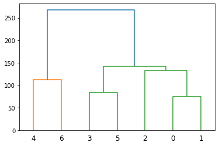

```python
# Hierachy Clustering by meanshift
ClusteringByHierarchy(ClusterCenterData_meanshift, FeatureList)
```

```
(7, 9)
```

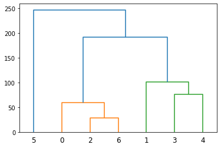

```python
# # Hierachy Clustering by kmeans
ClusteringByHierarchy(ClusterCenterData_kmeans, FeatureList)
```

```
(7, 9)
```

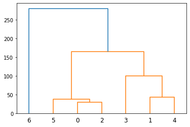

```python
# # Hierachy Clustering by em-gmm
ClusteringByHierarchy(ClusterGMMData, FeatureList)
```

### Merge các nhóm vào nhau theo từng TH Kmeans, EM-GMM, Meanshift và sau đó gán nhãn Survived là 0 và 1 sao cho đúng tần suất

### Xác định xem cách nào cho kết quả chính xác nhất

#### 1/ Kmeans

```python
# Create a dataframe of the predicted cluster numbers and survived labels
labels=data.survived
pred_labels=data['cluster_Kmeans']
df = pd.DataFrame({'clusternr':pred_labels,'survived':labels})

# Create a condition flagging fraud for the smallest clusters
df['predicted_survived'] = np.where((df['clusternr'].isin([ 0, 1, 2, 3, 4, 6])), 0 , 1)
```

```python
df
```

|  | clusternr | survived | predicted_survived |
| --- | --- | --- | --- |
| 0 | 5 | 1 | 1 |
| 1 | 1 | 1 | 0 |
| 2 | 1 | 0 | 0 |
| 3 | 1 | 0 | 0 |
| 4 | 1 | 0 | 0 |
| ... | ... | ... | ... |
| 1304 | 2 | 0 | 0 |
| 1305 | 2 | 0 | 0 |
| 1306 | 6 | 0 | 0 |
| 1307 | 6 | 0 | 0 |
| 1308 | 6 | 0 | 0 |

1239 rows × 3 columns

```python
df.predicted_survived.value_counts()
```

```
0    1205
1      34
Name: predicted_survived, dtype: int64
```

```python
from sklearn.metrics import accuracy_score
accuracy_score(df.survived,df.predicted_survived)
```

```
0.6142050040355125
```

#### 2/ meanshift

```python
# Create a dataframe of the predicted cluster numbers and survived labels
labels=data.survived
pred_labels=data['cluster_meanshift']
df = pd.DataFrame({'clusternr':pred_labels,'survived':labels})

# Create a condition flagging fraud for the smallest clusters
df['predicted_survived'] = np.where((df['clusternr'].isin([ 0, 1, 2, 3, 5])), 0 , 1)
```

```python
df
```

|  | clusternr | survived | predicted_survived |
| --- | --- | --- | --- |
| 0 | 4 | 1 | 1 |
| 1 | 3 | 1 | 0 |
| 2 | 3 | 0 | 0 |
| 3 | 3 | 0 | 0 |
| 4 | 3 | 0 | 0 |
| ... | ... | ... | ... |
| 1304 | 0 | 0 | 0 |
| 1305 | 0 | 0 | 0 |
| 1306 | 0 | 0 | 0 |
| 1307 | 0 | 0 | 0 |
| 1308 | 0 | 0 | 0 |

1239 rows × 3 columns

```python
df.predicted_survived.value_counts()
```

```
0    1205
1      34
Name: predicted_survived, dtype: int64
```

```python
from sklearn.metrics import accuracy_score
accuracy_score(df.survived,df.predicted_survived)
```

```
0.6142050040355125
```

#### 3/ EM-GMM

```python
# Create a dataframe of the predicted cluster numbers and survived labels
labels=data.survived
pred_labels=data['cluster_GMM']
df = pd.DataFrame({'clusternr':pred_labels,'survived':labels})

# Create a condition flagging fraud for the smallest clusters
df['predicted_survived'] = np.where((df['clusternr'].isin([ 0, 1, 2, 4, 5])), 0 , 1)
```

```python
df
```

|  | clusternr | survived | predicted_survived |
| --- | --- | --- | --- |
| 0 | 6 | 1 | 1 |
| 1 | 3 | 1 | 1 |
| 2 | 3 | 0 | 1 |
| 3 | 3 | 0 | 1 |
| 4 | 3 | 0 | 1 |
| ... | ... | ... | ... |
| 1304 | 0 | 0 | 0 |
| 1305 | 0 | 0 | 0 |
| 1306 | 0 | 0 | 0 |
| 1307 | 0 | 0 | 0 |
| 1308 | 0 | 0 | 0 |

1239 rows × 3 columns

```python
df.predicted_survived.value_counts()
```

```
0    1175
1      64
Name: predicted_survived, dtype: int64
```

```python
from sklearn.metrics import accuracy_score
accuracy_score(df.survived,df.predicted_survived)
```

```
0.6255044390637611
```

# FRAUD DETECTION BANKSIM

```python
path = r"C:\Users\Thanh\Documents\Data mining\Data_Mining_Lab08\\"
banksim_df = pd.read_csv(path + "banksim.csv")
banksim_df.drop(['Unnamed: 0'], axis=1, inplace=True)
banksim_adj_df = pd.read_csv(path + "banksim_adj.csv")
banksim_adj_df.drop(['Unnamed: 0'], axis=1, inplace=True)
```

```python
banksim_df.shape
```

```
(7200, 5)
```

```python
banksim_df.head()
```

|  | age | gender | category | amount | fraud |
| --- | --- | --- | --- | --- | --- |
| 0 | 3 | F | es_transportation | 49.71 | 0 |
| 1 | 4 | F | es_health | 39.29 | 0 |
| 2 | 3 | F | es_transportation | 18.76 | 0 |
| 3 | 4 | M | es_transportation | 13.95 | 0 |
| 4 | 2 | M | es_transportation | 49.87 | 0 |

```python
banksim_adj_df.shape
```

```
(7189, 18)
```

```python
banksim_adj_df.head()
```

|  | age | amount | fraud | M | es_barsandrestaurants | es_contents | es_fashion | es_food | es_health | es_home | es_hotelservices | es_hyper | es_leisure | es_otherservices | es_sportsandtoys | es_tech | es_transportation | es_travel |
| --- | --- | --- | --- | --- | --- | --- | --- | --- | --- | --- | --- | --- | --- | --- | --- | --- | --- | --- |
| 0 | 3 | 49.71 | 0 | 0 | 0 | 0 | 0 | 0 | 0 | 0 | 0 | 0 | 0 | 0 | 0 | 0 | 1 | 0 |
| 1 | 4 | 39.29 | 0 | 0 | 0 | 0 | 0 | 0 | 1 | 0 | 0 | 0 | 0 | 0 | 0 | 0 | 0 | 0 |
| 2 | 3 | 18.76 | 0 | 0 | 0 | 0 | 0 | 0 | 0 | 0 | 0 | 0 | 0 | 0 | 0 | 0 | 1 | 0 |
| 3 | 4 | 13.95 | 0 | 1 | 0 | 0 | 0 | 0 | 0 | 0 | 0 | 0 | 0 | 0 | 0 | 0 | 1 | 0 |
| 4 | 2 | 49.87 | 0 | 1 | 0 | 0 | 0 | 0 | 0 | 0 | 0 | 0 | 0 | 0 | 0 | 0 | 1 | 0 |

###### Group the data by transaction category and take the mean of the data.

```python
banksim_df.groupby(['category']).mean().sort_values(by=['fraud'], ascending=False)
```

| category | amount | fraud |
| --- | --- | --- |
| es_leisure | 229.757600 | 1.000000 |
| es_travel | 231.818656 | 0.944444 |
| es_sportsandtoys | 157.251737 | 0.657895 |
| es_otherservices | 149.648960 | 0.600000 |
| es_hotelservices | 172.756245 | 0.548387 |
| es_health | 126.604704 | 0.242798 |
| es_home | 120.688317 | 0.208333 |
| es_tech | 132.852862 | 0.179487 |
| es_hyper | 46.788180 | 0.125000 |
| es_wellnessandbeauty | 66.167078 | 0.060606 |
| es_barsandrestaurants | 43.841793 | 0.022472 |
| es_fashion | 59.780769 | 0.020619 |
| es_contents | 55.170000 | 0.000000 |
| es_food | 35.216050 | 0.000000 |
| es_transportation | 27.422014 | 0.000000 |

The majority of fraud is observed in travel, leisure and sports related transactions.

###### Group the dataframe df by the category age and get the means for each age group

```python
banksim_df.groupby(['age']).mean()
```

| age | amount | fraud |
| --- | --- | --- |
| 0 | 49.468935 | 0.050000 |
| 1 | 35.622829 | 0.026648 |
| 2 | 37.228665 | 0.028718 |
| 3 | 37.279338 | 0.023283 |
| 4 | 36.197985 | 0.035966 |
| 5 | 37.547521 | 0.023990 |
| 6 | 36.700852 | 0.022293 |
| U | 39.117000 | 0.000000 |

###### Count the values of each age group.

```python
banksim_df.age.value_counts()
```

```
2    2333
3    1718
4    1279
5     792
1     713
6     314
0      40
U      11
Name: age, dtype: int64
```

```python
# Create two dataframes with fraud and non-fraud data
df_fraud = banksim_df[banksim_df.fraud == 1]
df_non_fraud = banksim_df[banksim_df.fraud == 0]
```

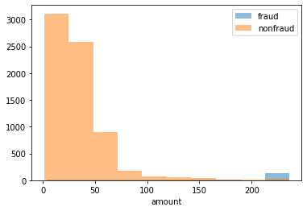

```python
# Plot histograms of the amounts in fraud and non-fraud data
plt.hist(df_fraud.amount, alpha=0.5, label='fraud')
plt.hist(df_non_fraud.amount, alpha=0.5, label='nonfraud')
plt.xlabel('amount')
plt.legend()
plt.show()
```

```python
# Import the packages
from sklearn.preprocessing import MinMaxScaler
from sklearn.cluster import KMeans

# Transform and scale your data
X = np.array(df).astype(np.float)
scaler = MinMaxScaler()
X_scaled = scaler.fit_transform(X)

# Define the k-means model and fit to the data
kmeans = KMeans(n_clusters=6, random_state=42).fit(X_scaled)
```

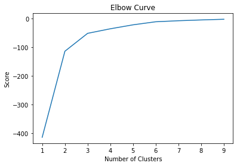

```python
clust = range(1, 10)
kmeans = [KMeans(n_clusters=i) for i in clust]

score = [kmeans[i].fit(X_scaled).score(X_scaled) for i in range(len(kmeans))]

plt.plot(clust,score)
plt.xlabel('Number of Clusters')
plt.ylabel('Score')
plt.title('Elbow Curve')
plt.show()
```

```python
labels = banksim_adj_df.fraud
```

```python
cols = ['age', 'amount', 'M', 'es_barsandrestaurants', 'es_contents',
        'es_fashion', 'es_food', 'es_health', 'es_home', 'es_hotelservices',
        'es_hyper', 'es_leisure', 'es_otherservices', 'es_sportsandtoys',
        'es_tech', 'es_transportation', 'es_travel']
```

```python
# Take the float values of df for X
X = banksim_adj_df[cols].values.astype(np.float)
```

```python
X.shape
```

```
(7189, 17)
```

```python
# Define the scaler and apply to the data
scaler = MinMaxScaler()
X_scaled = scaler.fit_transform(X)
```

```python
# Define the model
kmeans = MiniBatchKMeans(n_clusters=8, random_state=0)

# Fit the model to the scaled data
kmeans.fit(X_scaled)
```

```
MiniBatchKMeans(batch_size=100, compute_labels=True, init='k-means++',
        init_size=None, max_iter=100, max_no_improvement=10, n_clusters=8,
        n_init=3, random_state=0, reassignment_ratio=0.01, tol=0.0,
        verbose=0)
```

```python
# Define the range of clusters to try
clustno = range(1, 10)

# Run MiniBatch Kmeans over the number of clusters
kmeans = [MiniBatchKMeans(n_clusters=i) for i in clustno]

# Obtain the score for each model
score = [kmeans[i].fit(X_scaled).score(X_scaled) for i in range(len(kmeans))]
```

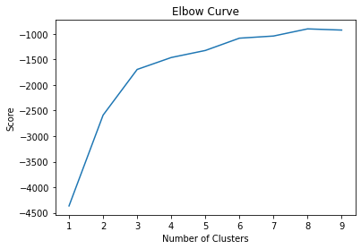

```python
# Plot the models and their respective score
plt.plot(clustno, score)
plt.xlabel('Number of Clusters')
plt.ylabel('Score')
plt.title('Elbow Curve')
plt.show()
```

```python
# Run the kmeans model on scaled data
kmeans = KMeans(n_clusters=6, random_state=42).fit(X_scaled)

# Get the cluster number for each datapoint
X_clusters = kmeans.predict(X_scaled)

# Save the cluster centroids
X_clusters_centers = kmeans.cluster_centers_

# Calculate the distance to the cluster centroid for each point
dist = [np.linalg.norm(x-y) for x,y in zip(X_scaled, X_clusters_centers[X_clusters])]

# Create predictions based on distance
km_y_pred = np.array(dist)
km_y_pred[dist>=np.percentile(dist, 93)] = 1
km_y_pred[dist<np.percentile(dist, 93)] = 0
```

```python
from sklearn.model_selection import train_test_split
# Split the data into training and test set
X_train, X_test, y_train, y_test = train_test_split(X_scaled, labels, test_size=0.3, random_state=0)

# Define K-means model
kmeans = MiniBatchKMeans(n_clusters=3, random_state=42).fit(X_train)

# Obtain predictions and calculate distance from cluster centroid
X_test_clusters = kmeans.predict(X_test)
X_test_clusters_centers = kmeans.cluster_centers_
dist = [np.linalg.norm(x-y) for x, y in zip(X_test, X_test_clusters_centers[X_test_clusters])]

# Create fraud predictions based on outliers on clusters
km_y_pred = np.array(dist)
km_y_pred[dist >= np.percentile(dist, 95)] = 1
km_y_pred[dist < np.percentile(dist, 95)] = 0
```

```python
def plot_confusion_matrix(cm, classes=['Not Fraud', 'Fraud'],
                          normalize=False,
                          title='Fraud Confusion matrix',
                          cmap=plt.cm.Blues):
    """
    This function prints and plots the confusion matrix.
    Normalization can be applied by setting `normalize=True`.
    From:
        http://scikit-learn.org/stable/auto_examples/model_selection/plot_confusion_matrix.html#sphx-glr-auto-
        examples-model-selection-plot-confusion-matrix-py
    """
    if normalize:
        cm = cm.astype('float') / cm.sum(axis=1)[:, np.newaxis]
        print("Normalized confusion matrix")
    else:
        print('Confusion matrix, without normalization')

    # print(cm)

    plt.imshow(cm, interpolation='nearest', cmap=cmap)
    plt.title(title)
    plt.colorbar()
    tick_marks = np.arange(len(classes))
    plt.xticks(tick_marks, classes, rotation=45)
    plt.yticks(tick_marks, classes)

    fmt = '.2f' if normalize else 'd'
    thresh = cm.max() / 2.
    for i, j in product(range(cm.shape[0]), range(cm.shape[1])):
        plt.text(j, i, format(cm[i, j], fmt),
                 horizontalalignment="center",
                 color="white" if cm[i, j] > thresh else "black")

    plt.tight_layout()
    plt.ylabel('True label')
    plt.xlabel('Predicted label')
    plt.show()
```

```python
from sklearn.metrics import roc_auc_score
# Obtain the ROC score
roc_auc_score(y_test, km_y_pred)
```

```
0.8109115999408585
```

```python
from sklearn.metrics import silhouette_score
from sklearn.cluster import DBSCAN
db = DBSCAN(eps=0.5, min_samples=10, n_jobs=-1).fit(X_scaled)

# Get the cluster labels (aka numbers)
pred_labels = db.labels_

# Count the total number of clusters
n_clusters_ = len(set(pred_labels)) - (1 if -1 in pred_labels else 0)

# Print model results
print(f'Estimated number of clusters: {n_clusters_}')


# Print model results
print(f'Silhouette Coefficient: {silhouette_score(X_scaled, pred_labels):0.3f}')

# Get sample counts in each cluster
counts = np.bincount(pred_labels[pred_labels>=0])
print(counts)
```

```
Estimated number of clusters: 22
Silhouette Coefficient: 0.712
[3252  145 2714   55  174  119  122   98   54   13   76   43   25   51
   47   42   15   15   19   23   18   10]
```

```python
# Initialize and fit the DBscan model
db = DBSCAN(eps=0.9, min_samples=10).fit(X_scaled)

# Obtain the predicted labels and calculate number of clusters
pred_labels = db.labels_
n_clusters = len(set(pred_labels)) - (1 if -1 in labels else 0)
```

```python
from sklearn.metrics import homogeneity_score

# Print performance metrics for DBscan
print(f'Estimated number of clusters: {n_clusters}')
print(f'Homogeneity: {homogeneity_score(labels, pred_labels):0.3f}')
print(f'Silhouette Coefficient: {silhouette_score(X_scaled, pred_labels):0.3f}')
```

```
Estimated number of clusters: 23
Homogeneity: 0.612
Silhouette Coefficient: 0.713
```

```python
# Count observations in each cluster number
counts = np.bincount(pred_labels[pred_labels >= 0])

# Print the result
print(counts)
```

```
[3252  145 2714   55  174  119  122   98   54   15   76   15   43   25
   51   47   42   15   25   20   19   10]
```

```python
# Create a dataframe of the predicted cluster numbers and fraud labels
df = pd.DataFrame({'clusternr':pred_labels,'fraud':labels})

# Create a condition flagging fraud for the smallest clusters
df['predicted_fraud'] = np.where((df['clusternr'].isin([21, 17, 9])), 1 , 0)
```

```python
# Run a crosstab on the results
print(pd.crosstab(df['fraud'], df['predicted_fraud'], rownames=['Actual Fraud'], colnames=['Flagged Fraud']))
```

```
Flagged Fraud     0   1
Actual Fraud
0              6973  16
1               176  24
```